# Model Comparison

Liah Cha

June 27, 2017

## Data Roles

- In sample : 개발에 사용된 데이터
- Out of sample : 개발에 사용되지 않은 동시점의 데이터
- Out of time : 개발 후 관찰된 데이터

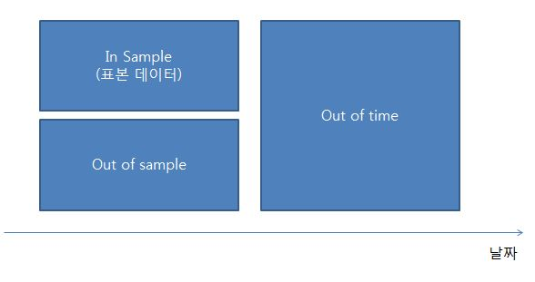

- In sample 데이터를 둘로 쪼개 Training 과 Test 데이터로 분리

#### Training Dataset

- The training set shold :
  - be **representative** of the entire data set
  - cover the full range of values for all the predictors that the model might encounter
  - contain a sufficient number of observations of rare events (i.e. balancing the outputs)
- A random sample of available data are not sufficient since the **rare observations** may not be chosen. Solution: startified sampling (층화 추출)
  - rare observation 케이스인 경우, 한쪽으로 쏠림 현상이 발생할 수 있으므로, training 과 test 데이터를 나눌 때 주의
  - 즉, 우량 고객 내에서 Training/Test 로 쪼개고, 불량 고객 내에서 Trainin/Test 데이터를 쪼갬

#### R example

```r
### Model Evaluation ###
#####Fitting by training data and validating by test data
buytest = read.table('./DMdata/buytest.txt',sep='\t',header=T)
head(buytest)
```

```
##          ID RESPOND AGE INCOME SEX MARRIED FICO OWNHOME LOC CLIMATE BUY6
## 1 001371057       0  71     67   M       1  719       0   A      10    1
## 2 002093270       0  53     72   M       1  751       0   A      10    0
## 3 002783726       0  53     70   F       1  725       0   A      10    1
## 4 010800860       0  45     56   F       0  684       0   A      10    0
## 5 014577797       0  32     66   F       0  651       0   A      10    0
## 6 015884859       0  35     48   F       0  691       1   A      10    0
##   BUY12 BUY18 VALUE24 ORGSRC DISCBUY RETURN24 COA6 C1 C2 C3 C4 C5 C6 C7
## 1     1     1     318      O       1        0    0  0  0  0  0  0  0  0
## 2     0     0      83      R       0        0    0  0  0  0  0  0  0  0
## 3     1     1     265      D       0        0    0  0  0  0  0  0  0  0
## 4     0     1     448      O       1        0    0  0  0  0  0  0  0  0
## 5     0     0     161      R       0        0    0  0  0  0  0  0  0  0
## 6     0     0     250      C       0        1    0  0  0  0  0  0  0  0
##   PURCHTOT
## 1        0
## 2        0
## 3        0
## 4        0
## 5        0
## 6        0
```

```r
set.seed(1234) # train/test 구분을 동일하게 할 수 있음, 같은 초기값을 줌
i = sample(1:nrow(buytest), round(nrow(buytest)*0.7)) #70% for training data, 30% for testdata
train = buytest[i,]
test = buytest[-i,]

paste0('Train: ',nrow(train), ', Test: ', nrow(test))
```

```
## [1] "Train: 7000, Test: 3000"
```

## Model Complexity

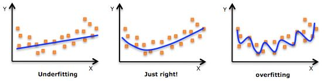

## Model comparison in Classification

- Accuracy
- **Lift chart**
- Profit chart
- **ROC curve**
- K-S statistics

## 1. Accuracy

#### Confusion Matrix

|  |  | Predicted Class |  |  |
| --- | --- | --- | --- | --- |
|  |  | 0 | 1 |  |
| Actual Class | 0 | **True Negative** | False Positive |  |
|  | 1 | False Negative | **True Positive** |  |

- Accuracy : 대각의 합/전체

|  |  | Predicted Class |  |  |  |
| --- | --- | --- | --- | --- | --- |
|  |  | Non-Buyer | Buyer |  |  |
| Actual Class | Non-buyer | 8500 | 500 | 9000 |  |
|  | Buyer | 500 | 500 | 1000 |  |
|  |  | 9000 | 1000 | 10000 |  |

#### Error Rates

```r
### 모형평가 ###
# na.omit -> missing value 가 있는 경우 제거

train=na.omit(train)
test=na.omit(test)
paste0('Train: ',nrow(train), ', Test: ', nrow(test))
```

```
## [1] "Train: 6819, Test: 2908"
```

```r
model1 = glm(RESPOND~AGE+BUY12+BUY18+FICO+MARRIED+OWNHOME,family=binomial(),data=train)
model2 = glm(RESPOND~AGE+FICO+MARRIED+OWNHOME,family=binomial(),data=train)
summary(model1)
```

```
##
## Call:
## glm(formula = RESPOND ~ AGE + BUY12 + BUY18 + FICO + MARRIED +
##     OWNHOME, family = binomial(), data = train)
##
## Deviance Residuals:
##     Min       1Q   Median       3Q      Max
## -1.0393  -0.4229  -0.3550  -0.2881   2.9362
##
## Coefficients:
##              Estimate Std. Error z value Pr(>|z|)
## (Intercept)  2.090903   1.133282   1.845  0.06504 .
## AGE         -0.040732   0.005479  -7.434 1.05e-13 ***
## BUY12       -0.587201   0.145647  -4.032 5.54e-05 ***
## BUY18        0.769198   0.102679   7.491 6.82e-14 ***
## FICO        -0.004792   0.001606  -2.984  0.00285 **
## MARRIED      0.685235   0.110195   6.218 5.02e-10 ***
## OWNHOME     -0.462573   0.107973  -4.284 1.83e-05 ***
## ---
## Signif. codes:  0 '***' 0.001 '**' 0.01 '*' 0.05 '.' 0.1 ' ' 1
##
## (Dispersion parameter for binomial family taken to be 1)
##
##     Null deviance: 3615.7  on 6818  degrees of freedom
## Residual deviance: 3455.3  on 6812  degrees of freedom
## AIC: 3469.3
##
## Number of Fisher Scoring iterations: 5
```

```r
summary(model2)
```

```
##
## Call:
## glm(formula = RESPOND ~ AGE + FICO + MARRIED + OWNHOME, family = binomial(),
##     data = train)
##
## Deviance Residuals:
##     Min       1Q   Median       3Q      Max
## -0.8623  -0.4332  -0.3689  -0.3014   2.9955
##
## Coefficients:
##              Estimate Std. Error z value Pr(>|z|)
## (Intercept)  2.452617   1.124838   2.180  0.02923 *
## AGE         -0.041877   0.005418  -7.729 1.09e-14 ***
## FICO        -0.004999   0.001596  -3.133  0.00173 **
## MARRIED      0.716290   0.109491   6.542 6.07e-11 ***
## OWNHOME     -0.478717   0.107500  -4.453 8.46e-06 ***
## ---
## Signif. codes:  0 '***' 0.001 '**' 0.01 '*' 0.05 '.' 0.1 ' ' 1
##
## (Dispersion parameter for binomial family taken to be 1)
##
##     Null deviance: 3615.7  on 6818  degrees of freedom
## Residual deviance: 3508.8  on 6814  degrees of freedom
## AIC: 3518.8
##
## Number of Fisher Scoring iterations: 5
```

```r
prob_pred1 = predict(model1, newdata=test, type='response') ## predicted probability
prob_pred2 = predict(model2, newdata=test, type='response') ## predicted probability
y_pred1 = as.numeric(prob_pred1 > 0.1)
tab1=table(test$RESPOND, y_pred1)
print(tab1)
```

```
##    y_pred1
##        0    1
##   0 2204  483
##   1  137   84
```

```r
sum(diag(tab1))/sum(tab1)
```

```
## [1] 0.786795
```

```r
y_pred2 = as.numeric(prob_pred2 > 0.1)
tab2=table(test$RESPOND, y_pred2)
print(tab2)
```

```
##    y_pred2
##        0    1
##   0 2178  509
##   1  153   68
```

```r
sum(diag(tab2))/sum(tab2)
```

```
## [1] 0.7723521
```

## 2. Lift (Gain) charts

- The scored data set is sorted by the posterior probabilities of the event level in descending order
- The observations are then grouped into deciles
- The x-axis is sample size or proportion
- The y-axis can be
  1. % Captured Response : 반응 검출율
  2. % Response : 반응율 (1등급 부터 후순위가 급경사를 이루는 모델이 좋은 모델)
  3. Lift : 향상도 (반응율/실제구매자비율= xx) –> 반응율이 xx배 늘어남

#### Generating a lift chart

[output not shown]

- Baseline Lift = 381/2000 = 19.05%

#### Cumulative table (누적)

- 튀는 케이스가 있는데, 누적 시키면 이경우를 잡아 일관되게 감소함을 확인할 수 있음

```r
### Lift Chart ###
scored_dat = cbind(prob_pred1,test$RESPOND)
head(scored_dat)
```

```
##    prob_pred1
## 1  0.03294272 0
## 2  0.04826081 0
## 3  0.06446029 0
## 5  0.08848204 0
## 13 0.03881891 0
## 20 0.20236998 0
```

```r
head(scored_dat[order(-prob_pred1),],30) # 확률의 내림 차순으로 정렬
```

```
##      prob_pred1
## 5626  0.4686767 0
## 3480  0.4283514 0
## 9398  0.4225472 1
## 8394  0.4201880 0
## 2513  0.3788265 0
## 8646  0.3576545 0
## 5807  0.3543776 0
## 2607  0.3402106 0
## 6161  0.3210928 0
## 3412  0.3185133 0
## 8874  0.3117947 1
## 4718  0.2916158 0
## 9110  0.2813422 0
## 1106  0.2746306 0
```

[output cut: 16 more lines]

- 좋은 모형이라면 구매확률이 높을 수록, 실제 구매자가 많아야 함
  - 상위 1,2등급내에 실제 구매자가 많아야 좋은 모형이라고 할 수 있음
- 10개의 등급을 만들어 줌
  - 예: 구매확률이 높은 상위 10%를 1등급으로 만듬

```
## [1] 0.07599725
```

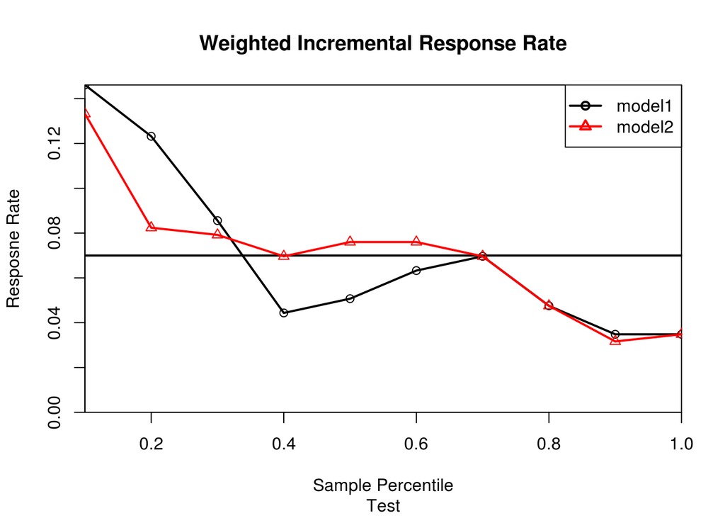

```
## [1] 2
```

```r
#install.packages("BCA",repos="http://healthstat.snu.ac.kr/CRAN/")
#install.packages("munsell",dependencies=TRUE,repos="http://healthstat.snu.ac.kr/CRAN/")
library(BCA)

#layout(matrix(c(1,2), 2, 1)) #차트를 한 화면에 2개 볼 수 있음
test$RESPOND=factor(test$RESPOND)
# targetLevel="1" 구매자 카운팅
# type="incremental" 누적아님
# trueResp = 0.07 실제 구매자의 비율
lift.chart(c("model1","model2"), data=test, targLevel="1",
    trueResp=0.07, type="incremental", sub="Test")
```

```
## [1] 0.07599725
```

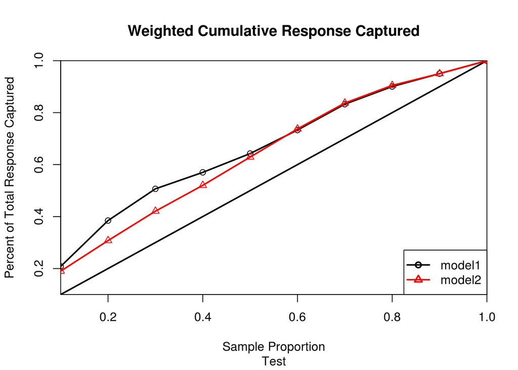

```r
# type="cumulative" 누적
lift.chart(c("model1","model2"), data=test, targLevel="1",
    trueResp=0.07, type="cumulative", sub="Test")
```

## 3. Profit chart

- expected profits or return on investment is an important measure
- how well the campaign works with information on cost
- to help with the decision of how to maximize profits (순익을 최대화)
- 비용과 매출, 수익구조를 고려한 Lift chart
- 단점 : 일반화 시키기는 어려움

## 4. R-Courve (** Recommended)

- ROC curves are similar to lift charts
- - y축: 민감도
  - x축 : 1-특이도
- 민감도와 특이도의 Cutoff value를 이용해서 그린 차트

#### Sensitivity & Specificity

- Sensitivity (민감도) : 구매자를 구매자로 찾아내는 능력
- Specificity (특이도) : 비구매자를 비구매자로 찾아내는 능력

|  |  | Predicted Class |  |  |
| --- | --- | --- | --- | --- |
|  |  | Yes | No |  |
| Actual Class | Yes | **Sensitivity** TP | 1-sensitivity FN |  |
|  | No | 1-specificity FP | **Specificity** TN |  |

#### AUROC

- Area under the ROC curve : AUROC = (Ar+1)/2
  - ROC 커브의 아래쪽 면적
- AUROC 의 max 값은 100%, min은 50%
  - 0.8 : good
  - 0.75 : moderate
  - 0.65 : 우리나라 최소기준
- AR 과 AUROC는 1:1 함수 관계에 있음

```r
### ROC커브 생성 ###
#install.packages("pROC",repos="http://healthstat.snu.ac.kr/CRAN/")
library(pROC)
```

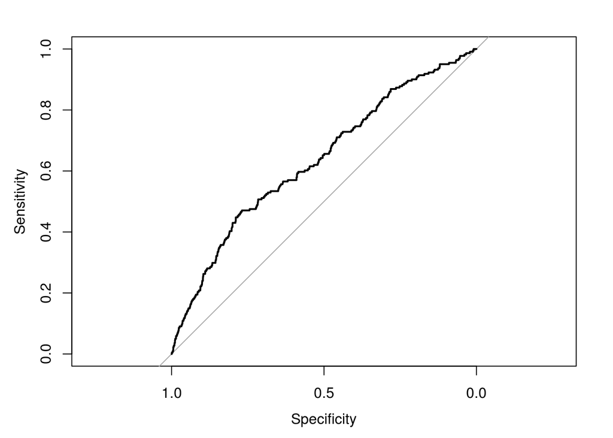

```r
roccurve1 <- roc(test$RESPOND ~ prob_pred1)
plot(roccurve1)
```

```r
auc(roccurve1) # AUROC
```

```
## Area under the curve: 0.6351
```

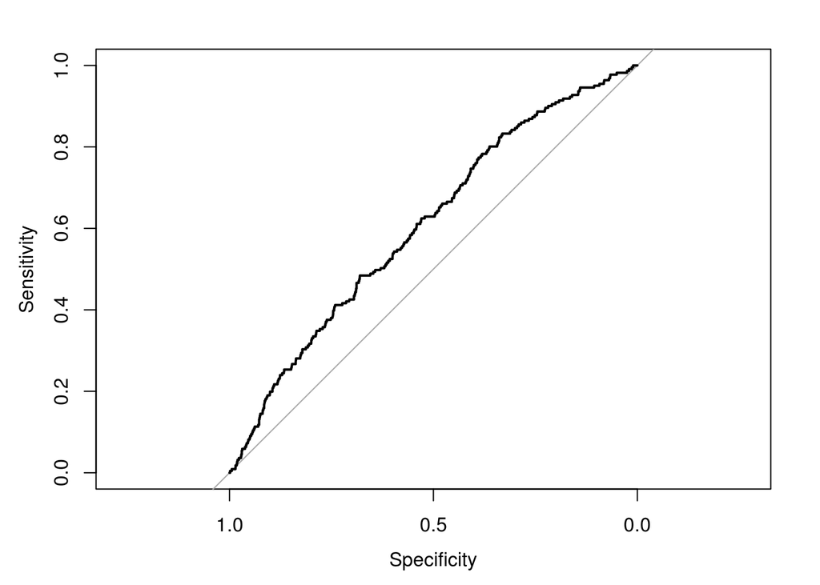

```r
roccurve2 <- roc(test$RESPOND ~ prob_pred2)
plot(roccurve2)
```

```r
auc(roccurve2) # AUROC
```

```
## Area under the curve: 0.6086
```

## 5. K-S statistics

```r
### K-S 검정 ###
ks.test(prob_pred1[test$RESPOND==1], prob_pred1[test$RESPOND==0])
```

```
##
##  Two-sample Kolmogorov-Smirnov test
##
## data:  prob_pred1[test$RESPOND == 1] and prob_pred1[test$RESPOND == 0]
## D = 0.23985, p-value = 1.252e-10
## alternative hypothesis: two-sided
```

```r
ks.test(prob_pred2[test$RESPOND==1], prob_pred2[test$RESPOND==0])
```

```
##
##  Two-sample Kolmogorov-Smirnov test
##
## data:  prob_pred2[test$RESPOND == 1] and prob_pred2[test$RESPOND == 0]
## D = 0.16448, p-value = 3.183e-05
## alternative hypothesis: two-sided
```